# A Corpus-Based Acoustic Analysis of Monophthong Vowels among Chinese Learners and Native Speakers of English - Part 3

Martin Schweinberger

2023-05-20

# Preparation

install packages

```r
# install
install.packages("tidyverse")
install.packages("here")
install.packages("adehabitatHR")
install.packages("lme4")
install.packages("sjPlot")
install.packages("report")
install.packages("flextable")
install.packages("cowplot")
install.packages("randomForest")
install.packages("rms")
install.packages("caret")
install.packages("Hmisc")
install.packages("glmulti")
install.packages("partykit")
install.packages("ggparty")
install.packages("hunspell")
install.packages("janitor")
install.packages("glmmTMB")
install.packages("quanteda")
```

load packages

```r
library(tidyverse)
library(here)
library(adehabitatHR)
library(lme4)
library(sjPlot)
library(report)
library(flextable)
library(cowplot)
library(randomForest)
library(rms)
library(caret)
library(Hmisc)
library(quanteda)
#library(glmulti)
library(partykit)
library(ggparty)
library(hunspell)
library(janitor)
# set options
options(stringsAsFactors = F)
options(scipen = 999)
options(max.print=10000)
```

# Load data

```r
# load .rda data
cdat  <- base::readRDS(file = here::here("data", "cleandat.rda")) %>%
  dplyr::ungroup()
# inspect
str(cdat); head(cdat)
```

```
## tibble [6,070 × 26] (S3: tbl_df/tbl/data.frame)
##  $ id      : chr [1:6070] "7" "7" "7" "11" ...
##  $ label   : chr [1:6070] "{" "Q" "I" "u:" ...
##  $ word    : chr [1:6070] "that" "was" "with" "do" ...
##  $ file    : chr [1:6070] "SM_CHN_PTJ1_001_B1_1" "SM_CHN_PTJ1_001_B1_1" "SM_CHN_PTJ1_001_B1_1" "SM_CHN_PTJ1_001_B1_1" ...
##  $ F1      : num [1:6070] 714 638 479 508 593 ...
##  $ F2      : num [1:6070] 1357 1169 996 1238 1791 ...
##  $ speaker : chr [1:6070] "CHN001" "CHN001" "CHN001" "CHN001" ...
##  $ vowel   : chr [1:6070] "æ" "ɒ" "ɪ" "uː" ...
##  $ type    : chr [1:6070] "CHN" "CHN" "CHN" "CHN" ...
##  $ gender  : chr [1:6070] "m" "m" "m" "m" ...
##  $ Age     : int [1:6070] 20 20 20 20 20 19 20 20 20 20 ...
##  $ tvariety: chr [1:6070] "us" "us" "us" "us" ...
##  $ edist   : num [1:6070] 399 146 1033 234 301 ...
##  $ barkF1  : num [1:6070] 6.63 6.05 4.73 4.99 5.7 ...
##  $ barkF2  : num [1:6070] 10.44 9.49 8.5 9.85 12.27 ...
##  $ fspeaker: chr [1:6070] "CHN001" "CHN001" "CHN001" "CHN001" ...
##  $ lobF1   : num [1:6070, 1] 1.198 0.596 -0.665 -0.43 0.244 ...
##  $ lobF2   : num [1:6070, 1] -0.308 -0.8 -1.254 -0.618 0.83 ...
##  $ duration: num [1:6070] 0.21 0.2 0.06 0.06 0.08 ...
##  $ normF1  : num [1:6070] 714 638 479 508 593 ...
##  $ normF2  : num [1:6070] 1357 1169 996 1238 1791 ...
##  $ cF1     : num [1:6070] 5.96 6.08 5.04 4.07 5.04 ...
##  $ cF2     : num [1:6070] 10.7 10.6 11.5 10.7 11.5 ...
##  $ ED      : num [1:6070] 0.715 1.126 3 1.261 1.024 ...
##  $ WordType: chr [1:6070] "grammatical" "grammatical" "grammatical" "grammatical" ...
##  $ prof    : Factor w/ 3 levels "A2","B1","B2": 2 2 2 2 2 2 2 2 2 2 ...
```

```
## # A tibble: 6 × 26
##   id    label word  file      F1    F2 speaker vowel type  gender   Age tvariety
##   <chr> <chr> <chr> <chr>  <dbl> <dbl> <chr>   <chr> <chr> <chr>  <int> <chr>
## 1 7     {     that  SM_CH…  714. 1357. CHN001  æ     CHN   m         20 us
## 2 7     Q     was   SM_CH…  638. 1169. CHN001  ɒ     CHN   m         20 us
## 3 7     I     with  SM_CH…  479.  996. CHN001  ɪ     CHN   m         20 us
## 4 11    u:    do    SM_CH…  508. 1238. CHN001  uː    CHN   m         20 us
## 5 27    I     with  SM_CH…  593. 1791. CHN002  ɪ     CHN   m         20 us
## 6 47    I     this  SM_CH…  860. 1553. CHN003  ɪ     CHN   m         19 us
## # ℹ 14 more variables: edist <dbl>, barkF1 <dbl>, barkF2 <dbl>, fspeaker <chr>,
## #   lobF1 <dbl[,1]>, lobF2 <dbl[,1]>, duration <dbl>, normF1 <dbl>,
## #   normF2 <dbl>, cF1 <dbl>, cF2 <dbl>, ED <dbl>, WordType <chr>, prof <fct>
```

# Reduce data

```r
bdat <- cdat %>%
  dplyr::mutate(label = stringr::str_remove_all(label, ":"),
                gender = ifelse(gender == "f", "female", gender),
                gender = ifelse(gender == "m", "male", gender),
                tvariety = ifelse(tvariety == "us", "AmE", tvariety),
                tvariety = ifelse(tvariety == "gb", "BrE", tvariety)) %>%
#  dplyr::filter(label != "A",
#                label != "O") %>%
  droplevels(.)  %>%
  dplyr::rename(Vowel = label,
                Word = word,
                TargetVariety = tvariety,
                Gender = gender,
                Duration = duration,
                Proficiency = prof,
                Speaker = speaker) %>%
  # clean word
  dplyr::mutate(Word = str_remove_all(Word, "\\W")) %>%
  dplyr::filter(hunspell_check(Word) == T) %>%
  # remove "shits"
  dplyr::filter(Word != "shits",
                Word != "stat",
                Word != "whats")
# inspect
head(bdat); names(table(bdat$Word))
```

```
## # A tibble: 6 × 26
##   id    Vowel Word  file               F1    F2 Speaker vowel type  Gender   Age
##   <chr> <chr> <chr> <chr>           <dbl> <dbl> <chr>   <chr> <chr> <chr>  <int>
## 1 7     {     that  SM_CHN_PTJ1_00…  714. 1357. CHN001  æ     CHN   male      20
## 2 7     Q     was   SM_CHN_PTJ1_00…  638. 1169. CHN001  ɒ     CHN   male      20
## 3 7     I     with  SM_CHN_PTJ1_00…  479.  996. CHN001  ɪ     CHN   male      20
## 4 11    u     do    SM_CHN_PTJ1_00…  508. 1238. CHN001  uː    CHN   male      20
## 5 27    I     with  SM_CHN_PTJ1_00…  593. 1791. CHN002  ɪ     CHN   male      20
## 6 47    I     this  SM_CHN_PTJ1_00…  860. 1553. CHN003  ɪ     CHN   male      19
## # ℹ 15 more variables: TargetVariety <chr>, edist <dbl>, barkF1 <dbl>,
## #   barkF2 <dbl>, fspeaker <chr>, lobF1 <dbl[,1]>, lobF2 <dbl[,1]>,
## #   Duration <dbl>, normF1 <dbl>, normF2 <dbl>, cF1 <dbl>, cF2 <dbl>, ED <dbl>,
## #   WordType <chr>, Proficiency <fct>
```

```
##  [1] "bad"     "be"      "best"    "big"     "bit"     "book"    "books"
##  [8] "boost"   "boss"    "buds"    "bus"     "but"     "butts"   "dad"
## [15] "dead"    "death"   "debt"    "debts"   "depth"   "did"     "do"
## [22] "due"     "gap"     "gas"     "get"     "gets"    "good"    "got"
## [29] "guess"   "had"     "has"     "he"      "head"    "his"     "hit"
## [36] "keep"    "kept"    "key"     "kids"    "pass"    "past"    "path"
## [43] "peak"    "pub"     "push"    "put"     "sad"     "said"    "sat"
## [50] "saw"     "says"    "seat"    "seats"   "see"     "seep"    "sees"
## [57] "set"     "sets"    "she"     "shoes"   "shop"    "shops"   "sit"
## [64] "speak"   "spots"   "step"    "stop"    "stud"    "suit"    "task"
## [71] "taught"  "teeth"   "test"    "that"    "this"    "thought" "thus"
## [78] "too"     "took"    "top"     "tough"   "two"     "was"     "wash"
## [85] "we"      "weak"    "week"    "what"    "who"     "wish"    "with"
```

# Check frequency of words

```r
# create a vector of words
words <- names(table(bdat$Word))
# load ace files
afiles <- list.files(here::here("ACE"), pattern = ".TXT", recursive = T, full.names = T)
bfiles <- list.files(here::here("BROWN"), pattern = ".TXT", recursive = T, full.names = T)
lfiles <- list.files(here::here("LOB"), pattern = ".TXT", recursive = T, full.names = T)
cfiles <- c(afiles, bfiles, lfiles)
```

```r
# load the files by scanning the content
controlc <- sapply(cfiles, function(x){
  x <- scan(x, what = "char",  sep = "", quote = "",  quiet = T,  skipNul = T)
  x <- paste0(x, sep = " ", collapse = " ")
  x <- stringr::str_squish(x)
})
controlc <- paste0(controlc, collapse = " ")
# inspect
str(controlc)
```

```
##  chr "<section> <X> A: PRESS REPORTAGE </X> <X> NOTE: THIS SECTION KEYED FROM HARDCOPY} </X> <sample><X> A01 </X> <X>"| __truncated__
```

extract word count of control corpus

```r
cleancontrolc <- controlc %>%
  stringr::str_replace_all("<.*?>", " ") %>%
  stringr::str_replace_all("[^[:alpha:] ]", " ") %>%
  stringr::str_squish() %>%
  quanteda::tokenize_fastestword() %>%
  unlist() %>%
  length()
# inspect
cleancontrolc
```

```
## [1] 5199986
```

check how frequent the words are in the control corpus

```r
freqs <- sapply(words, function(x){
  x <- stringr::str_count(controlc, paste0("\\W", x, "\\W", sep = "", collapse = ""))
})
# convert into data frame
freqsdf <- data.frame(names(freqs), freqs, cleancontrolc) %>%
  dplyr::rename(Word = 1,
                all = 3) %>%
  dplyr::mutate(Frequency = log(freqs/all*1000)) %>%
  dplyr::select(-freqs, -all)
# inspect
head(freqsdf)
```

```
##      Word Frequency
## bad   bad -2.537818
## be     be  1.247808
## best best -1.632783
## big   big -2.018271
## bit   bit -2.577525
## book book -2.082521
```

## Annotate word class

```r
lexical <- c("bad",  "bed", "best", "big", "bit", "book", "books", "boost", "boots", "boss", "bought", "buds", "bus", "butts", "dad", "dead", "death", "debt", "debts", "desk", "dish",  "dust", "gap", "gas",  "good",  "guess", "head", "heads",  "hit", "hot", "key", "kid", "kids", "pass", "past", "pat", "path", "pub", "pubs", "push", "sad", "said", "sat", "says", "seat", "seats", "see", "seep", "sees", "set", "sets",  "shits", "shoes", "shop", "shops", "shut", "sit", "skip",  "speak", "spots", "stat", "step", "steps", "stop", "stops", "stud", "suit", "task", "tasks", "tea", "teeth", "test", "tests", "took", "top", "tough", "two", "wash", "ways",  "weak", "weed", "week",  "wish",  "wood")
bdat <- bdat %>%
  dplyr::mutate(WordClass = ifelse(Word %in% lexical, "lexical", "grammatical"),
                Word = as.vector(Word))
bdat <- left_join(bdat, freqsdf, by = "Word")
# inspect
table(bdat$WordClass); head(bdat)
```

```
##
## grammatical     lexical
##        5187         881
```

```
## # A tibble: 6 × 28
##   id    Vowel Word  file               F1    F2 Speaker vowel type  Gender   Age
##   <chr> <chr> <chr> <chr>           <dbl> <dbl> <chr>   <chr> <chr> <chr>  <int>
## 1 7     {     that  SM_CHN_PTJ1_00…  714. 1357. CHN001  æ     CHN   male      20
## 2 7     Q     was   SM_CHN_PTJ1_00…  638. 1169. CHN001  ɒ     CHN   male      20
## 3 7     I     with  SM_CHN_PTJ1_00…  479.  996. CHN001  ɪ     CHN   male      20
## 4 11    u     do    SM_CHN_PTJ1_00…  508. 1238. CHN001  uː    CHN   male      20
## 5 27    I     with  SM_CHN_PTJ1_00…  593. 1791. CHN002  ɪ     CHN   male      20
## 6 47    I     this  SM_CHN_PTJ1_00…  860. 1553. CHN003  ɪ     CHN   male      19
## # ℹ 17 more variables: TargetVariety <chr>, edist <dbl>, barkF1 <dbl>,
## #   barkF2 <dbl>, fspeaker <chr>, lobF1 <dbl[,1]>, lobF2 <dbl[,1]>,
## #   Duration <dbl>, normF1 <dbl>, normF2 <dbl>, cF1 <dbl>, cF2 <dbl>, ED <dbl>,
## #   WordType <chr>, Proficiency <fct>, WordClass <chr>, Frequency <dbl>
```

## Check durations

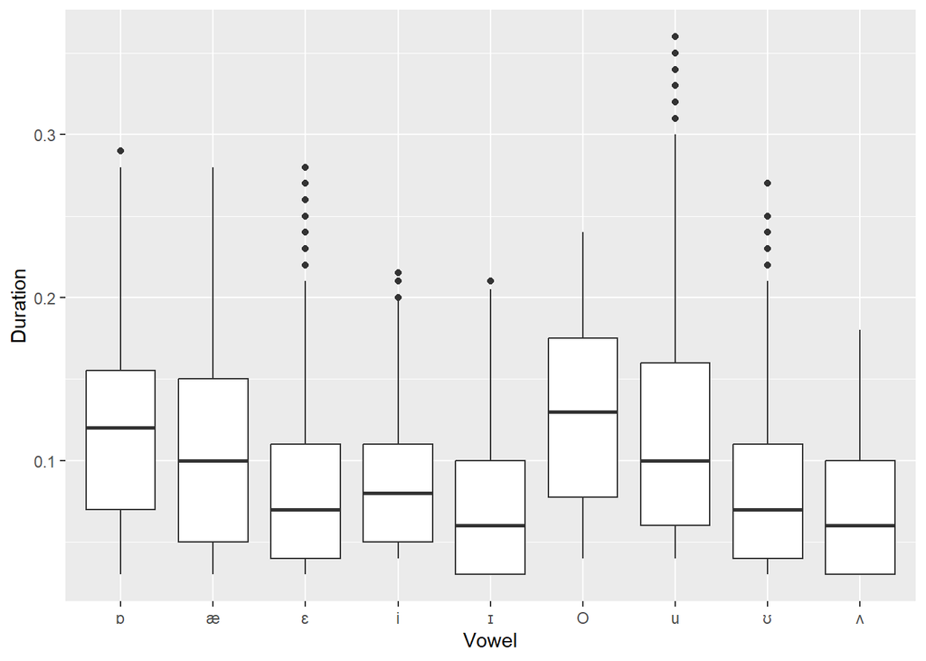

```r
bdat %>%
  dplyr::mutate(Vowel = dplyr::case_when(Vowel == "{" ~ "\u00E6",
                                         Vowel == "6" ~ "\u0250",
                                         Vowel == "e" ~ "\u0065",
                                         Vowel == "E" ~ "\u025B",
                                         Vowel == "i" ~ "\u0069",
                                         Vowel == "I" ~ "\u026A",
                                         Vowel == "Q" ~ "\u0252",
                                         Vowel == "u" ~ "\u0075",
                                         Vowel == "U" ~ "\u028A",
                                         Vowel == "V" ~ "\u028C",
                                         TRUE ~ Vowel))  %>%
  ggplot(aes(x = Vowel, y = Duration)) +
  geom_boxplot()
```

```r
nrow(bdat)
```

```
## [1] 6068
```

```r
bdat <- bdat  %>%
  # remove rare words
  dplyr::group_by(type, Word) %>%
  dplyr::mutate(freq = n()) %>%
#  dplyr::mutate(Word = ifelse(freq > 10, Word, "other")) %>%
  dplyr::ungroup()
# harmonize words
nnwords <- bdat %>%
  dplyr::filter(type == "CHN") %>%
  dplyr::group_by(Word) %>%
  dplyr::summarise(Freq = n()) %>%
  dplyr::pull(Word)

# remove rare vowels
bdat <- bdat %>%
  dplyr::group_by(Vowel) %>%
  dplyr::mutate(fr = n()) %>%
  dplyr::filter(fr > 100) %>%
  dplyr::select(-fr) %>%
  dplyr::ungroup()
# inspect
str(bdat); nrow(bdat)
```

```
## tibble [6,045 × 29] (S3: tbl_df/tbl/data.frame)
##  $ id           : chr [1:6045] "7" "7" "7" "11" ...
##  $ Vowel        : chr [1:6045] "{" "Q" "I" "u" ...
##  $ Word         : chr [1:6045] "that" "was" "with" "do" ...
##  $ file         : chr [1:6045] "SM_CHN_PTJ1_001_B1_1" "SM_CHN_PTJ1_001_B1_1" "SM_CHN_PTJ1_001_B1_1" "SM_CHN_PTJ1_001_B1_1" ...
##  $ F1           : num [1:6045] 714 638 479 508 593 ...
##  $ F2           : num [1:6045] 1357 1169 996 1238 1791 ...
##  $ Speaker      : chr [1:6045] "CHN001" "CHN001" "CHN001" "CHN001" ...
##  $ vowel        : chr [1:6045] "æ" "ɒ" "ɪ" "uː" ...
##  $ type         : chr [1:6045] "CHN" "CHN" "CHN" "CHN" ...
##  $ Gender       : chr [1:6045] "male" "male" "male" "male" ...
##  $ Age          : int [1:6045] 20 20 20 20 20 19 20 20 20 20 ...
##  $ TargetVariety: chr [1:6045] "AmE" "AmE" "AmE" "AmE" ...
##  $ edist        : num [1:6045] 399 146 1033 234 301 ...
##  $ barkF1       : num [1:6045] 6.63 6.05 4.73 4.99 5.7 ...
##  $ barkF2       : num [1:6045] 10.44 9.49 8.5 9.85 12.27 ...
##  $ fspeaker     : chr [1:6045] "CHN001" "CHN001" "CHN001" "CHN001" ...
##  $ lobF1        : num [1:6045, 1] 1.198 0.596 -0.665 -0.43 0.244 ...
##  $ lobF2        : num [1:6045, 1] -0.308 -0.8 -1.254 -0.618 0.83 ...
##  $ Duration     : num [1:6045] 0.21 0.2 0.06 0.06 0.08 ...
##  $ normF1       : num [1:6045] 714 638 479 508 593 ...
##  $ normF2       : num [1:6045] 1357 1169 996 1238 1791 ...
##  $ cF1          : num [1:6045] 5.96 6.08 5.04 4.07 5.04 ...
##  $ cF2          : num [1:6045] 10.7 10.6 11.5 10.7 11.5 ...
##  $ ED           : num [1:6045] 0.715 1.126 3 1.261 1.024 ...
##  $ WordType     : chr [1:6045] "grammatical" "grammatical" "grammatical" "grammatical" ...
##  $ Proficiency  : Factor w/ 3 levels "A2","B1","B2": 2 2 2 2 2 2 2 2 2 2 ...
##  $ WordClass    : chr [1:6045] "grammatical" "grammatical" "grammatical" "grammatical" ...
##  $ Frequency    : num [1:6045] 1.692 1.632 1.302 -0.408 1.302 ...
##  $ freq         : int [1:6045] 365 19 291 154 291 222 365 255 10 187 ...
```

```
## [1] 6045
```

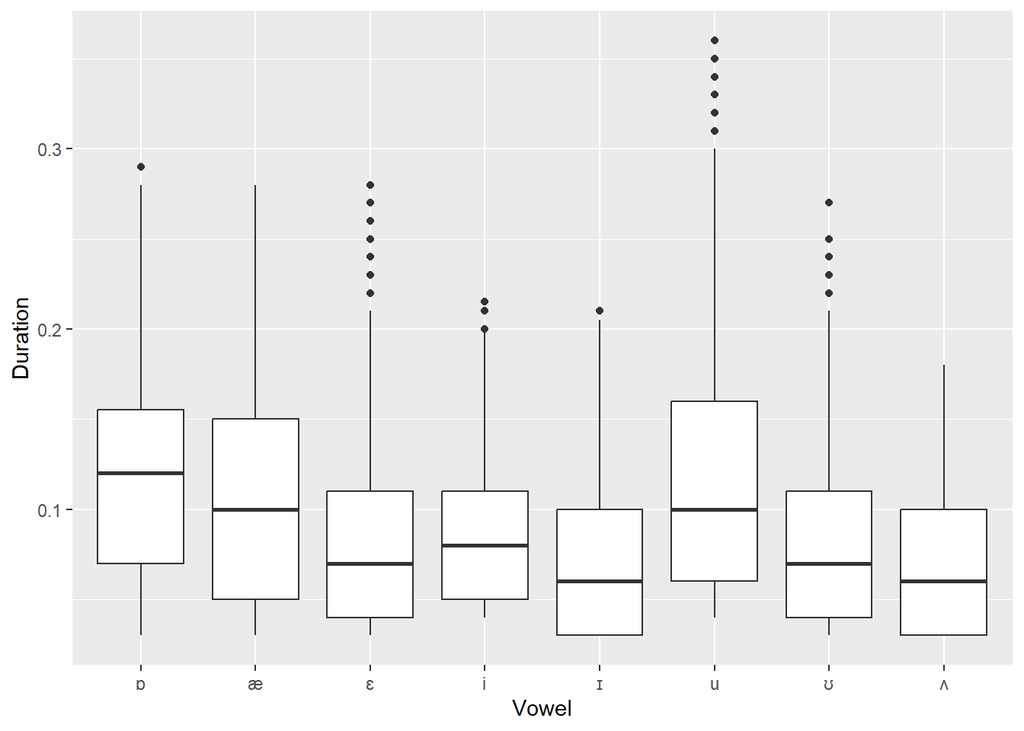

```r
bdat %>%
  dplyr::mutate(Vowel = dplyr::case_when(Vowel == "{" ~ "\u00E6",
                                         Vowel == "6" ~ "\u0250",
                                         Vowel == "e" ~ "\u0065",
                                         Vowel == "E" ~ "\u025B",
                                         Vowel == "i" ~ "\u0069",
                                         Vowel == "I" ~ "\u026A",
                                         Vowel == "Q" ~ "\u0252",
                                         Vowel == "u" ~ "\u0075",
                                         Vowel == "U" ~ "\u028A",
                                         Vowel == "V" ~ "\u028C",
                                         TRUE ~ Vowel))  %>%
  ggplot(aes(x = Vowel, y = Duration)) +
  geom_boxplot()
```

```r
tb2 <- bdat %>%
  dplyr::ungroup() %>%
  dplyr::mutate(Age = dplyr::case_when(Age < 30 ~ "18-29",
                                       Age < 40 ~ "30-39",
                                       Age < 50 ~ "40-49",
                                       Age > 49 ~ "50+",
                                       TRUE ~ "unknown")) %>%
  dplyr::group_by(type, Gender, Age) %>%
  dplyr::summarise(speakers = length(table(Speaker))) %>%
  tidyr::spread(Age, speakers) %>%
  dplyr::ungroup()  %>%
  adorn_totals("row")%>%
  adorn_totals("col")
# save
write.table(tb2, here::here("tables", "tb2_icame.txt"), sep = "\t")
# inspect
tb2
```

```
##   type Gender 18-29 30-39 Total
##    CHN female    85     1    86
##    CHN   male    60     2    62
##    ENS female    25     5    30
##    ENS   male    30    27    57
##  Total      -   200    35   235
```

```r
bdat <- bdat %>%
  dplyr::mutate(F1 = as.vector(scale(F1)),
                F2 = as.vector(scale(F2)),
                Duration = as.vector(scale(Duration)),
                Age = as.vector(scale(Age)))
```

# Mixed-Model

Prepare data

Find frequent words (N > 5) that occur in both ENS and CHN data (WARNING: based on words determined to be shared in the ENS train, ENS test and CHN data for the MuPDARF)

```r
nswords <- c("bad", "be", "best", "big", "book", "books", "boss", "but", "did", "do", "due", "gas", "get", "gets", "good", "got", "guess", "had", "has", "he", "his", "keep", "kids", "other", "past", "pub", "put", "said", "see", "she", "sit", "step", "stop", "stud", "teeth", "that", "this", "too", "took", "tough", "two", "was", "we", "what", "who", "wish", "with")
```

process data and make it ready for GLMM

```r
mdat <- bdat %>%
  dplyr::filter(Vowel == "i"|Vowel == "I"|Vowel == "u"|Vowel == "U"|Vowel == "E"|Vowel == "{") %>%
  dplyr::select(-Vowel, -TargetVariety, -edist, -barkF1, -barkF2, -lobF1,
                -lobF2, -normF1, -normF2, -cF1, -cF2, -ED, -WordType, -freq, -file, -id, -fspeaker) %>%
  dplyr::rename(Vowel = vowel) %>%
  dplyr::mutate(Word = ifelse(Word %in% nswords, Word, "other")) %>%
  dplyr::mutate_if(is.character, factor)
  # inspect
str(mdat)
```

```
## tibble [5,434 × 12] (S3: tbl_df/tbl/data.frame)
##  $ Word       : Factor w/ 38 levels "bad","be","best",..: 30 38 8 38 31 30 2 6 13 30 ...
##  $ F1         : num [1:5434] 1.26053 -0.18463 -0.00193 0.52037 2.15964 ...
##  $ F2         : num [1:5434] -0.491 -1.5409 -0.8348 0.7723 0.0812 ...
##  $ Speaker    : Factor w/ 235 levels "CHN001","CHN002",..: 1 1 1 2 3 4 4 4 4 5 ...
##  $ Vowel      : Factor w/ 6 levels "æ","ɛ","ɪ","iː",..: 1 3 6 3 3 2 4 5 5 1 ...
##  $ type       : Factor w/ 2 levels "CHN","ENS": 1 1 1 1 1 1 1 1 1 1 ...
##  $ Gender     : Factor w/ 2 levels "female","male": 2 2 2 2 2 1 1 1 1 2 ...
##  $ Age        : num [1:5434] -0.737 -0.737 -0.737 -0.737 -0.921 ...
##  $ Duration   : num [1:5434] 2.195 -0.554 -0.554 -0.187 -1.104 ...
##  $ Proficiency: Factor w/ 3 levels "A2","B1","B2": 2 2 2 2 2 2 2 2 2 2 ...
##  $ WordClass  : Factor w/ 2 levels "grammatical",..: 1 1 1 1 1 1 1 2 2 1 ...
##  $ Frequency  : num [1:5434] 1.692 1.302 -0.408 1.302 0.705 ...
```

Baseline model

```r
# set options
options(contrasts  =c("contr.treatment", "contr.poly"))
mdat.dist <- datadist(mdat)
options(datadist = "mdat.dist")
# generate initial minimal regression model
# baseline model glm
ma = glmer(Duration ~ (1 | Word) + (1|Speaker), family = gaussian, data = mdat)
# inspect results
summary(ma)
```

```
## Linear mixed model fit by REML ['lmerMod']
## Formula: Duration ~ (1 | Word) + (1 | Speaker)
##    Data: mdat
##
## REML criterion at convergence: 14818.3
##
## Scaled residuals:
##     Min      1Q  Median      3Q     Max
## -2.3073 -0.7243 -0.1816  0.5908  4.4406
##
## Random effects:
##  Groups   Name        Variance Std.Dev.
##  Speaker  (Intercept) 0.1085   0.3295
##  Word     (Intercept) 0.1638   0.4047
##  Residual             0.8318   0.9120
## Number of obs: 5434, groups:  Speaker, 235; Word, 38
##
## Fixed effects:
##             Estimate Std. Error t value
## (Intercept)  0.07388    0.07752   0.953
```

```r
# inspect
sjPlot::tab_model(ma)
```

|  | Duration |  |  |
| --- | --- | --- | --- |
| Predictors | Estimates | CI | p |
| (Intercept) | 0.07 | -0.08 – 0.23 | 0.341 |
| Random Effects |  |  |  |
| σ<sup>2</sup> | 0.83 |  |  |
| τ<sub>00</sub> <sub>Speaker</sub> | 0.11 |  |  |
| τ<sub>00</sub> <sub>Word</sub> | 0.16 |  |  |
| ICC | 0.25 |  |  |
| N <sub>Word</sub> | 38 |  |  |
| N <sub>Speaker</sub> | 235 |  |  |
| Observations | 5434 |  |  |
| Marginal R<sup>2</sup> / Conditional R<sup>2</sup> | 0.000 / 0.247 |  |  |

Model fitting

```r
# wrapper function for linear mixed-models
glmer.glmulti <- function(formula, data, random="",...){
  lmer(paste(deparse(formula),random),  data=data, ...)
}
# define formular
form_glmulti = as.formula(paste("Duration ~  Vowel + type +  Gender + WordClass"))
```

```r
library(glmulti)
# multi selection for glmer
mfit <- glmulti(form_glmulti, random="+(1|Speaker)+(1|Word)",
                data = mdat, method = "h", fitfunc = glmer.glmulti,  includeobjects = T,
                crit = "aic", intercept = TRUE, marginality = FALSE, level = 2)
```

After 50 models: Best model: Duration~1+Vowel+type+Gender+type:Vowel+Gender:Vowel Best model: Duration~1+Vowel+type+Gender+type:Vowel+Gender:Vowel+Gender:type Crit= 15875.9439868615 Mean crit= 16152.5991758241

After 100 models: Best model: Duration~1+Vowel+type+Gender+WordClass+Gender:Vowel Best model: Duration~1+Vowel+type+Gender+WordClass+Gender:Vowel+WordClass:Vowel Best model: Duration~1+Vowel+type+Gender+WordClass+Gender:Vowel+WordClass:type Best model: Duration~1+Vowel+type+Gender+WordClass+Gender:Vowel+WordClass:Vowel+WordClass:type Best model: Duration~1+Vowel+type+Gender+WordClass+Gender:Vowel+WordClass:Gender Best model: Duration~1+Vowel+type+Gender+WordClass+Gender:Vowel+WordClass:Vowel+WordClass:Gender Best model: Duration~1+Vowel+type+Gender+WordClass+Gender:Vowel+WordClass:type+WordClass:Gender Best model: Duration~1+Vowel+type+Gender+WordClass+Gender:Vowel+WordClass:Vowel+WordClass:type+WordClass:Gender Crit= 15869.1516948654 Mean crit= 16099.4464548991 Completed.

```r
mb <- lmer(Duration ~ (1 | Word) + (1|Speaker) +
             type + Vowel + Gender + WordClass + Gender:Vowel,
           data = mdat)
# inspect
sjPlot::tab_model(ma, mb)
```

|  | Duration |  |  | Duration |  |  |
| --- | --- | --- | --- | --- | --- | --- |
| Predictors | Estimates | CI | p | Estimates | CI | p |
| (Intercept) | 0.07 | -0.08 – 0.23 | 0.341 | -0.05 | -0.23 – 0.14 | 0.612 |
| type [ENS] |  |  |  | -0.43 | -0.51 – -0.34 | **<0.001** |
| Vowel [ɛ] |  |  |  | 0.13 | -0.01 – 0.27 | 0.072 |
| Vowel [ɪ] |  |  |  | -0.53 | -0.74 – -0.32 | **<0.001** |
| Vowel [iː] |  |  |  | 0.14 | -0.06 – 0.35 | 0.169 |
| Vowel [ʊ] |  |  |  | -0.20 | -0.51 – 0.10 | 0.190 |
| Vowel [uː] |  |  |  | 1.06 | 0.79 – 1.32 | **<0.001** |
| Gender [male] |  |  |  | 0.80 | 0.68 – 0.92 | **<0.001** |
| WordClass [lexical] |  |  |  | 0.28 | 0.11 – 0.45 | **0.002** |
| Vowel [ɛ] × Gender [male] |  |  |  | -0.74 | -0.92 – -0.56 | **<0.001** |
| Vowel [ɪ] × Gender [male] |  |  |  | -0.26 | -0.41 – -0.12 | **<0.001** |
| Vowel [iː] × Gender [male] |  |  |  | -0.75 | -0.89 – -0.60 | **<0.001** |
| Vowel [ʊ] × Gender [male] |  |  |  | -0.79 | -1.02 – -0.56 | **<0.001** |
| Vowel [uː] × Gender [male] |  |  |  | -1.26 | -1.45 – -1.07 | **<0.001** |
| Random Effects |  |  |  |  |  |  |
| σ<sup>2</sup> | 0.83 |  |  | 0.78 |  |  |
| τ<sub>00</sub> | 0.11 <sub>Speaker</sub> |  |  | 0.06 <sub>Speaker</sub> |  |  |
|  | 0.16 <sub>Word</sub> |  |  | 0.03 <sub>Word</sub> |  |  |
| ICC | 0.25 |  |  | 0.11 |  |  |
| N | 38 <sub>Word</sub> |  |  | 38 <sub>Word</sub> |  |  |
|  | 235 <sub>Speaker</sub> |  |  | 235 <sub>Speaker</sub> |  |  |
| Observations | 5434 |  |  | 5434 |  |  |
| Marginal R<sup>2</sup> / Conditional R<sup>2</sup> | 0.000 / 0.247 |  |  | 0.179 / 0.266 |  |  |

Visualize effects

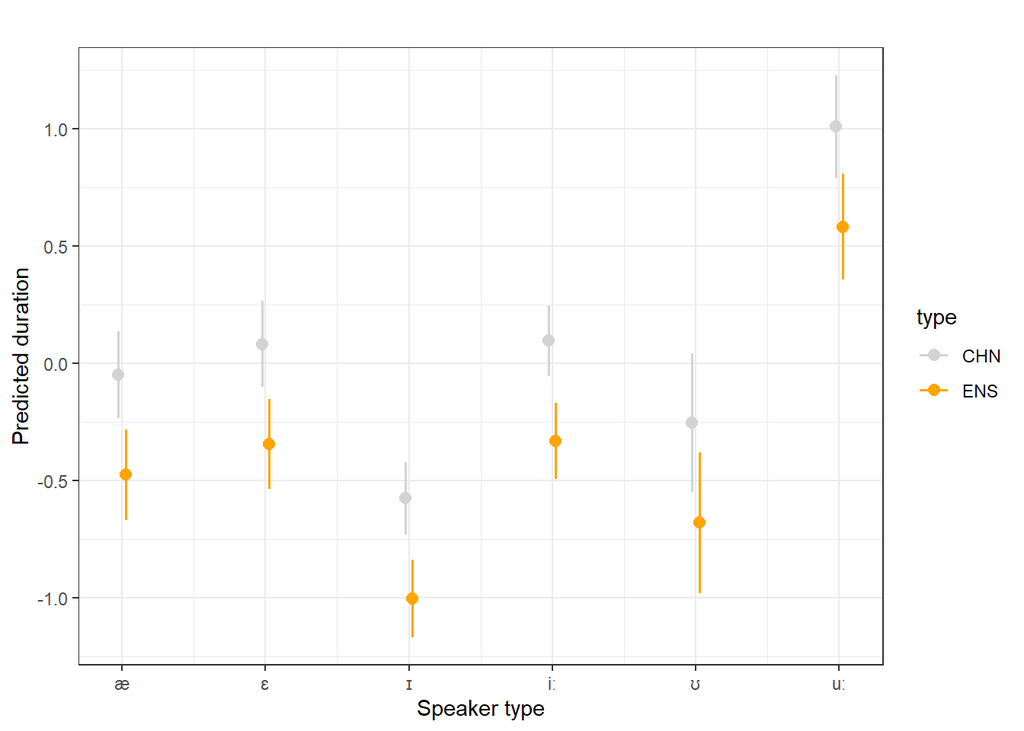

```r
sjPlot::plot_model(mb, type = "pred", terms = c("Vowel", "type")) +
  scale_color_manual(values = c("lightgray", "orange")) +
  theme_bw() +
  labs(title = "", y = "Predicted duration", x = "Speaker type")
```

```r
ggsave2(here::here("images", "lmer_type.png"), width = 4, height = 3)
```

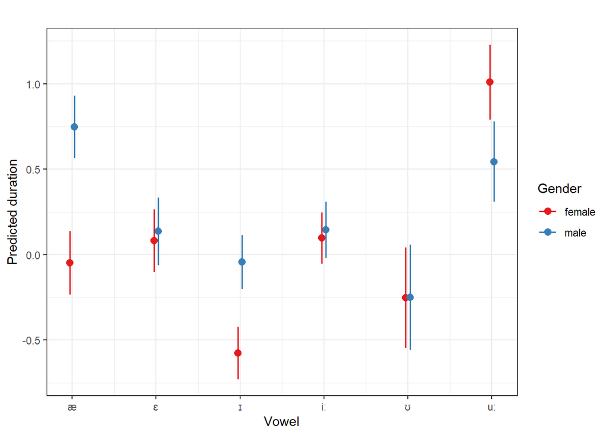

```r
sjPlot::plot_model(mb, type = "pred", terms = c("Vowel", "Gender")) +
  theme_bw() +
  labs(title = "", y = "Predicted duration")
```

```r
ggsave2(here::here("images", "lmer_vowelf2.png"), width = 4, height = 3)
```

# Overlap

Check density

```r
wordplot3 <- function(fdat, vwl1, vwl2){
  plt <- fdat %>%
    dplyr::rename(label = Vowel)  %>%
    dplyr::filter(label == vwl1 | label == vwl2) %>%
    dplyr::group_by(Word, label) %>%
    dplyr::mutate(meanF2 = mean(lobF2),
                  meanF1 = mean(lobF1)) %>%
    dplyr::ungroup() %>%
    dplyr::group_by(label) %>%
    dplyr::mutate(cF2 = mean(lobF2),
                  cF1 = mean(lobF1)) %>%
    # plot
    ggplot(aes(x = lobF2, y = lobF1)) +
  stat_density_2d(geom = "polygon",
                  aes(alpha = ..level.., fill = label), bins = 8)  +
    facet_grid( ~ type) +
    scale_x_reverse(position = "top") +
    scale_y_reverse(position = "right") +
    #scale_fill_distiller(palette = "Blues", direction = 1) +
    geom_text(aes(x = meanF2, y = meanF1,
                  label = Word, color = label), size = 4) +
    geom_text(aes(x = cF2, y = cF1,
                  label = vowel), size = 6, color = "gray20") +
    theme_minimal() +
    theme(panel.grid.major = element_blank(),
                  panel.grid.minor = element_blank(),
                  legend.position = "none") +
  scale_color_manual(values = c("orange3", "gray40")) +
  scale_fill_manual(values = c("orange", "gray")) +
    labs(x = "Formant 2 (Lobanov normalized)", y = "Formant 1 (Lobanov normalized)")
  return(plt)
  }
```

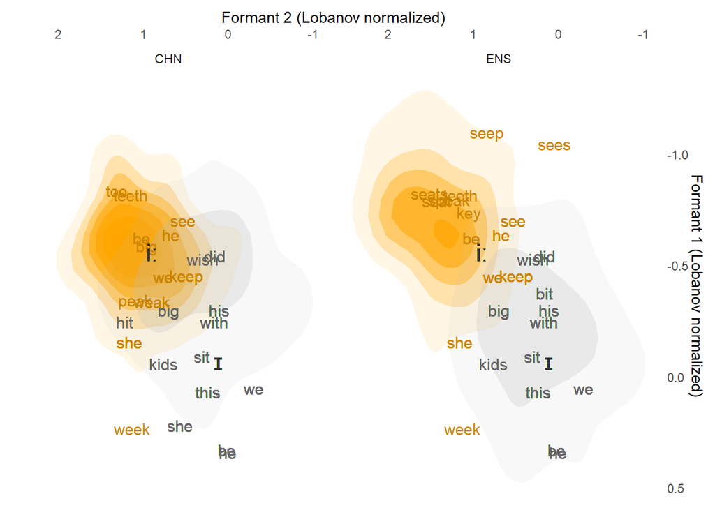

```r
pIi <- wordplot3(fdat = bdat, vwl1 = "I", vwl2 = "i")
ggsave(here::here("images", "pIi.png"), height = 3,  width = 5, dpi = 320)
pIi
```

```r
wordplot3 <- function(fdat, vwl1, vwl2){
  plt <- fdat %>%
    dplyr::rename(label = Vowel)  %>%
    dplyr::filter(label == vwl1 | label == vwl2) %>%
    dplyr::group_by(Word, label) %>%
    dplyr::mutate(meanF2 = mean(lobF2),
                  meanF1 = mean(lobF1)) %>%
    dplyr::ungroup() %>%
    dplyr::group_by(label) %>%
    dplyr::mutate(cF2 = mean(lobF2),
                  cF1 = mean(lobF1)) %>%
    # plot
    ggplot(aes(x = lobF2, y = lobF1)) +
  stat_density_2d(geom = "polygon",
                  aes(alpha = ..level.., fill = label), bins = 8)  +
    facet_grid( ~ type) +
    scale_x_reverse(position = "top") +
    scale_y_reverse(position = "right") +
    #scale_fill_distiller(palette = "Blues", direction = 1) +
    geom_text(aes(x = meanF2, y = meanF1,
                  label = Word, color = label), size = 4) +
    geom_text(aes(x = cF2, y = cF1,
                  label = vowel), size = 6, color = "gray20") +
    theme_minimal() +
    theme(panel.grid.major = element_blank(),
                  panel.grid.minor = element_blank(),
                  legend.position = "none") +
  scale_color_manual(values = c("red", "darkblue")) +
  scale_fill_manual(values = c("salmon", "lightblue")) +
    labs(x = "Formant 2 (Lobanov normalized)", y = "Formant 1 (Lobanov normalized)")
  return(plt)
  }
```

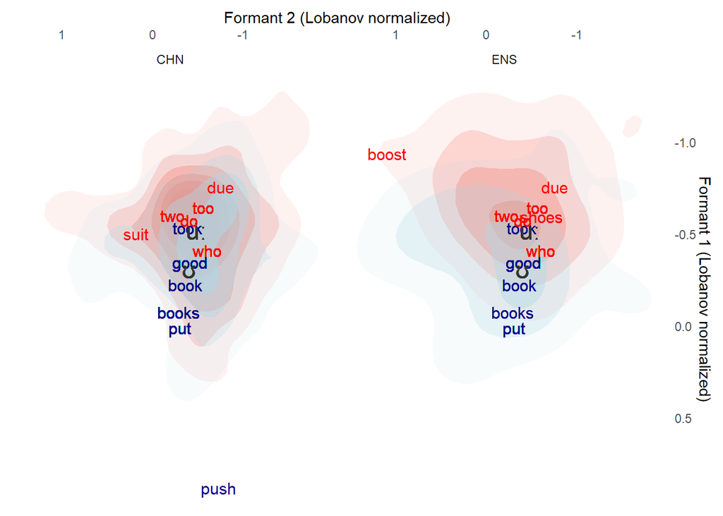

```r
pUu <- wordplot3(fdat = bdat, vwl1 = "U", vwl2 = "u")
ggsave(here::here("images", "pUu.png"), height = 3,  width = 5, dpi = 320)
pUu
```

```r
wordplot3 <- function(fdat, vwl1, vwl2){
  plt <- fdat %>%
    dplyr::rename(label = Vowel)  %>%
    dplyr::filter(label == vwl1 | label == vwl2) %>%
    dplyr::group_by(Word, label) %>%
    dplyr::mutate(meanF2 = mean(lobF2),
                  meanF1 = mean(lobF1)) %>%
    dplyr::ungroup() %>%
    dplyr::group_by(label) %>%
    dplyr::mutate(cF2 = mean(lobF2),
                  cF1 = mean(lobF1)) %>%
    # plot
    ggplot(aes(x = lobF2, y = lobF1)) +
  stat_density_2d(geom = "polygon",
                  aes(alpha = ..level.., fill = label), bins = 8)  +
    facet_grid( ~ type) +
    scale_x_reverse(position = "top") +
    scale_y_reverse(position = "right") +
    #scale_fill_distiller(palette = "Blues", direction = 1) +
    geom_text(aes(x = meanF2, y = meanF1,
                  label = Word, color = label), size = 4) +
    geom_text(aes(x = cF2, y = cF1,
                  label = vowel), size = 6, color = "gray20") +
    theme_minimal() +
    theme(panel.grid.major = element_blank(),
                  panel.grid.minor = element_blank(),
                  legend.position = "none") +
  scale_color_manual(values = c("green", "darkorchid4")) +
  scale_fill_manual(values = c("lightgreen", "darkorchid1")) +
    labs(x = "Formant 2 (Lobanov normalized)", y = "Formant 1 (Lobanov normalized)")
  return(plt)
  }
```

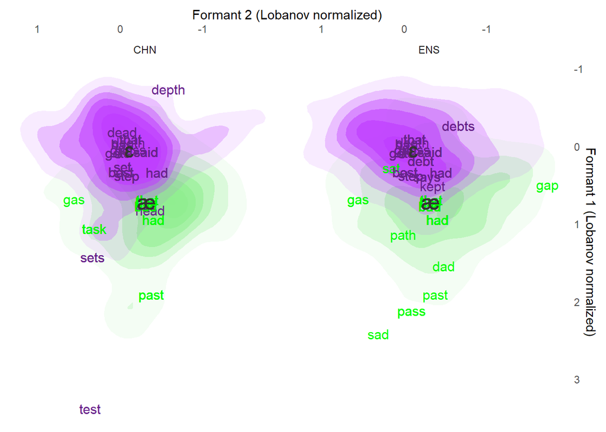

```r
pEe <- wordplot3(fdat = bdat, vwl1 = "{", vwl2 = "E")
ggsave(here::here("images", "pEe.png"), height = 3,  width = 5, dpi = 320)
pEe
```

# Bhattacharyya’s affinity

function for extracting Bhattacharyya’s affinity by type and target variety

```r
exba <- function(data, section, target, vwl1, vwl2){
  ba <- data %>%
  ungroup() %>%
  dplyr::filter(type == section,
                TargetVariety == target,
                Vowel == vwl1 | Vowel == vwl2)

  ba_formants <- ba %>%  dplyr::select(lobF1, lobF2)
  # extract vowels
  ba_vowel <- ba %>%  dplyr::select(vowel)
  # spatial data frame
  ba_spdf <- SpatialPointsDataFrame(ba_formants, ba_vowel)
  # calculate Bhattacharyya's affinity
  ba_ba <- kerneloverlap(ba_spdf, method = "BA")
  # result
  return(ba_ba[1,2])
}
```

## I vs i:

```r
# CHN
exba(data = bdat, section = "CHN", target = "AmE", vwl1 = "I", vwl2 = "i")
```

```
## [1] 0.833733
```

```r
# ENS
exba(data = bdat, section = "ENS", target = "AmE", vwl1 = "I", vwl2 = "i")
```

```
## [1] 0.692465
```

## U vs u:

High-back

```r
# CHN
exba(data = bdat, section = "CHN", target = "AmE", vwl1 = "U", vwl2 = "u")
```

```
## [1] 0.9570087
```

```r
# ENS
exba(data = bdat, section = "ENS", target = "AmE", vwl1 = "U", vwl2 = "u")
```

```
## [1] 0.9389342
```

## E vs {

```r
# CHN
exba(data = bdat, section = "CHN", target = "AmE", vwl1 = "{", vwl2 = "E")
```

```
## [1] 0.7969477
```

```r
# ENS
exba(data = bdat, section = "ENS", target = "AmE", vwl1 = "{", vwl2 = "E")
```

```
## [1] 0.8161988
```

# Tabulation of the data

```r
tb1 <- bdat %>%
  dplyr::filter(Vowel == "{"|Vowel == "E"|Vowel == "i"|Vowel == "I"|Vowel == "u"|Vowel == "U")  %>%
  dplyr::mutate(Vowel = dplyr::case_when(Vowel == "{" ~ "\u00E6",
                                         Vowel == "6" ~ "\u0250",
                                         Vowel == "e" ~ "\u0065",
                                         Vowel == "E" ~ "\u025B",
                                         Vowel == "i" ~ "\u0069",
                                         Vowel == "I" ~ "\u026A",
                                         Vowel == "Q" ~ "\u0252",
                                         Vowel == "u" ~ "\u0075",
                                         Vowel == "U" ~ "\u028A",
                                         Vowel == "V" ~ "\u028C",
                                         TRUE ~ Vowel))  %>%
  dplyr::ungroup() %>%
  dplyr::group_by(type) %>%
  dplyr::mutate(speakers = length(table(Speaker))) %>%
  dplyr::ungroup() %>%
  dplyr::group_by(type, Vowel) %>%
  dplyr::summarise(speakers = speakers,
                   obs = n()) %>%
  unique() %>%
  tidyr::spread(Vowel, obs) %>%
  dplyr::ungroup()  %>%
  adorn_totals("row")%>%
  adorn_totals("col") %>%
  dplyr::mutate(Total = Total-speakers)
# save
write.table(tb1, here::here("tables", "tb1_icame.txt"), sep = "\t")
# inspect
tb1
```

```
##   type speakers    æ   ɛ    i    ɪ   u   ʊ Total
##    CHN      148  514 228  723  795 278 219  2757
##    ENS       87  869 340  660  443 255 110  2677
##  Total      235 1383 568 1383 1238 533 329  5434
```

tabulate proficiency

```r
tb3 <- bdat %>%
  dplyr::ungroup() %>%
  dplyr::filter(type == "CHN")%>%
  dplyr::group_by(Proficiency, Gender) %>%
  dplyr::summarise(speakers = length(table(Speaker))) %>%
  tidyr::spread(Proficiency, speakers) %>%
  dplyr::ungroup()  %>%
  adorn_totals("row")%>%
  adorn_totals("col")
# save
write.table(tb3, here::here("tables", "tb3_icame.txt"), sep = "\t")
# inspect
tb3
```

```
##  Gender A2  B1 B2 Total
##  female  9  70  7    86
##    male  5  55  2    62
##   Total 14 125  9   148
```

```r
summary(bdat)
```

```
##       id               Vowel               Word               file
##  Length:6045        Length:6045        Length:6045        Length:6045
##  Class :character   Class :character   Class :character   Class :character
##  Mode  :character   Mode  :character   Mode  :character   Mode  :character
##
##
##
##        F1                F2             Speaker             vowel
##  Min.   :-3.1334   Min.   :-2.77247   Length:6045        Length:6045
##  1st Qu.:-0.7491   1st Qu.:-0.67226   Class :character   Class :character
##  Median :-0.1399   Median :-0.06886   Mode  :character   Mode  :character
##  Mean   : 0.0000   Mean   : 0.00000
##  3rd Qu.: 0.5633   3rd Qu.: 0.68958
##  Max.   : 6.8375   Max.   : 3.70697
##      type              Gender               Age          TargetVariety
##  Length:6045        Length:6045        Min.   :-1.4704   Length:6045
##  Class :character   Class :character   1st Qu.:-0.7372   Class :character
##  Mode  :character   Mode  :character   Median :-0.3707   Mode  :character
##                                        Mean   : 0.0000
##                                        3rd Qu.: 0.5458
##                                        Max.   : 2.7452
##      edist              barkF1            barkF2         fspeaker
##  Min.   :   8.902   Min.   :-0.1505   Min.   : 5.529   Length:6045
##  1st Qu.: 283.101   1st Qu.: 3.8923   1st Qu.:10.133   Class :character
##  Median : 566.421   Median : 4.7978   Median :11.101   Mode  :character
##  Mean   : 603.628   Mean   : 4.9092   Mean   :11.055
##  3rd Qu.: 881.121   3rd Qu.: 5.7559   3rd Qu.:12.164
##  Max.   :2202.267   Max.   :11.5982   Max.   :15.240
##       lobF1.V1             lobF2.V1          Duration           normF1
##  Min.   :-2.979996   Min.   :-2.8473359   Min.   :-1.1035   Min.   :   0.0
##  1st Qu.:-0.598647   1st Qu.:-0.6403746   1st Qu.:-0.9203   1st Qu.: 388.8
##  Median :-0.182367   Median :-0.0562365   Median :-0.1873   Median : 486.6
##  Mean   : 0.014394   Mean   : 0.0139520   Mean   : 0.0000   Mean   : 510.0
##  3rd Qu.: 0.498100   3rd Qu.: 0.7011739   3rd Qu.: 0.5458   3rd Qu.: 601.7
##  Max.   : 5.542780   Max.   : 2.9906909   Max.   : 4.9439   Max.   :1627.4
##      normF2            cF1             cF2              ED
##  Min.   : 572.2   Min.   :4.069   Min.   :10.12   Min.   :0.00499
##  1st Qu.:1298.9   1st Qu.:4.091   1st Qu.:10.70   1st Qu.:0.79529
##  Median :1506.0   Median :5.042   Median :11.12   Median :1.20366
##  Mean   :1529.5   Mean   :4.992   Mean   :11.36   Mean   :1.43929
##  3rd Qu.:1766.3   3rd Qu.:5.723   3rd Qu.:11.49   3rd Qu.:1.75981
##  Max.   :2799.9   Max.   :6.081   Max.   :12.85   Max.   :7.51071
##    WordType         Proficiency  WordClass           Frequency
##  Length:6045        A2  : 299   Length:6045        Min.   :-7.4578
##  Class :character   B1  :2537   Class :character   1st Qu.:-0.2910
##  Mode  :character   B2  : 223   Mode  :character   Median : 0.7054
##                     NA's:2986                      Mean   : 0.3815
##                                                    3rd Qu.: 1.3023
##                                                    Max.   : 1.6920
##       freq
##  Min.   :  1
##  1st Qu.:102
##  Median :222
##  Mean   :340
##  3rd Qu.:572
##  Max.   :874
```

```r
summary(mdat)
```

```
##       Word            F1                F2              Speaker     Vowel
##  that   :1239   Min.   :-3.1334   Min.   :-2.77247   ENS107 :  59   æ :1383
##  be     : 841   1st Qu.:-0.8066   1st Qu.:-0.56563   ENS082 :  57   ɛ : 568
##  we     : 633   Median :-0.2340   Median : 0.03572   CHN119 :  50   ɪ :1238
##  with   : 478   Mean   :-0.0586   Mean   : 0.07880   ENS039 :  48   iː:1383
##  this   : 347   3rd Qu.: 0.4713   3rd Qu.: 0.77585   ENS056 :  47   ʊ : 329
##  good   : 281   Max.   : 6.8375   Max.   : 3.70697   ENS106 :  46   uː: 533
##  (Other):1615                                        (Other):5127
##   type         Gender          Age               Duration        Proficiency
##  CHN:2757   female:2843   Min.   :-1.470358   Min.   :-1.10354   A2  : 272
##  ENS:2677   male  :2591   1st Qu.:-0.737226   1st Qu.:-0.73703   B1  :2278
##                           Median :-0.370659   Median :-0.18726   B2  : 207
##                           Mean   :-0.009018   Mean   : 0.02257   NA's:2677
##                           3rd Qu.: 0.545756   3rd Qu.: 0.54576
##                           Max.   : 2.745154   Max.   : 4.94389
##
##        WordClass      Frequency
##  grammatical:4611   Min.   :-7.4578
##  lexical    : 823   1st Qu.:-0.2384
##                     Median : 0.7054
##                     Mean   : 0.4259
##                     3rd Qu.: 1.3023
##                     Max.   : 1.6920
##
```

# Outro

```r
# save tables
base::saveRDS(mdat, file = here::here("tables", "mdat.rda"))
base::saveRDS(bdat, file = here::here("tables", "bdat.rda"))
```

# Citation & Session Info

Schweinberger, Martin and Ruihua Yin. 2023. A Corpus-Based Acoustic Analysis of Monophthongal Vowels among Chinese Learners and Native Speakers of English. Brisbane: The University of Queensland, School of Languages and Cultures.